# Trabajo Final de Estadística

[figure not shown]

## Caso de Análisis

*El conjunto de datos de Ventas en línea de SalesUsa es un registro de las ventas de diferentes productos, mercancias, artefactos electrónicos en diferentes estados. Dado que una gran parte de las personas que tiene accesos a Internet se están cambiando a las compras en línea, los grandes minoristas están buscando activamente formas de aumentar sus ganancias.*

*Por esa razón presentamos los objetivos principales*

> Analizar de la cesta de la compra y encontrar la relaciones entre los articulos más relevantes

> Identificar las oportunidades de mejora en nuestro servicio de ventas en linea.

> Identifica los puntos fuertes en base al historial sistema de ventas de Sales USA.

*Para iniciar con en análisis vamos a comenzar con la identificación de variables*

### Definición de variables

*Se cuenta con una tabla de datos de 35 variables*

Definición de variables

| **N°** | **Variable** | **Descripción de la variable** | **Tipo de variable** |
| --- | --- | --- | --- |
| *1* | *order_id* | *Identificador de la orden* | *Cualitativa Nominal* |
| *2* | *order_date* | *Fecha de la orden* | *Cuantitativa discreta* |
| *3* | *status* | *Estatus del orden* | *Cualitativa ordinal* |
| *4* | *item_id* | *Identificador del item* | *Calitativa Nominal* |
| *5* | *sku* | *Descripción del item* | *Cualitativa Nominal* |
| *6* | *cant_ordened* | *Cantidad de items adquiridos en la orden* | *Cuantitativa Discreta* |
| *7* | *price* | *Precio unitario del item* | *Cuantitativa Continua* |
| *8* | *value* | *Precio general del los items adquiridos* | *Cuantitativa Continua* |
| *9* | *discount_amount* | *Descuento total de los items* | *Cuantitativa Continua* |
| *10* | *total* | *Precio total de los items* | *Cuantitativa Continua* |
| *11* | *category* | *Categoria al cual pertenece la orden* | *Cualitativa Nominal* |
| *12* | *payment_method* | *Método de pago* | *Cualitativa Nominal* |
| *13* | *bi_st* | *No se tiene registro* | *Cualitativa Nominal* |
| *14* | *cust_id* | *ID del cliente o customer id* | *Cualitativa Nominal* |
| *15* | *year* | *Año de la compra* | *Cuantitativa discreta* |
| *16* | *month* | *Mes de la compra* | *Cuantitativa discreta* |
| *17* | *ref_num* | *Número de referencia* | *Cuantitativa discreta* |
| *18* | *Name Prefix* | *Prefijo del nombre* | *Cualitativa ordinal* |
| *19* | *First Name* | *Primer nombre* | *Cualitativa nominal* |
| *20* | *Middle Initial* | *Sin detalle del campo* | *Cualitativa nominal* |
| *21* | *Last Name* | *Apellido del cliente* | *Cualitativa nominal* |
| *22* | *Gender* | *Genero del cliente* | *Cualitativa nominal/binaria* |
| *23* | *age* | *Edad del cliente* | *Cuantitativa discreta* |
| *24* | *full_name* | *Nombre completo del cliente* | *Cualitativa nominal* |
| *25* | *E Mail* | *Correo electrónico del cliente* | *Cualitativa nominal* |
| *26* | *Customer Since* | *Fecha de registro del cliente* | *Cuantitativa discreta* |
| *27* | *SSN* | *Número de seguro social* | *Cualitativa nominal* |
| *28* | *Phone No.* | *Número telefónico del cliente* | *Cualitativa nominal* |
| *29* | *Place Name* | *Nombre del lugar de residencia* | *Cualitativa nominal* |
| *30* | *County* | *País* | *Cualitativa nominal* |
| *31* | *City* | *Ciudad* | *Cualitativa nominal* |
| *32* | *State* | *Estado* | *Cualitativa nominal* |
| *33* | *Zip* | *Código Postal* | *Cualitativa nominal* |
| *34* | *Region* | *Región* | *Cualitativa nominal* |
| *35* | *User Name* | *Nombre del usuario* | *Cualitativa nominal* |

## **Análisis Descriptivo**

**Para el planteamiento del caso USA Store se analizará las ventas generadas**

**Preguntas comerciales**

- ¿Qué región/estados es la más rentable?
- ¿Qué categorías generan más ganancias en las ventas?
- ¿Cuales son los Status por ventas?
- ¿Que tipo de pago es el mas usado?
- ¿Que genero tiene mayores ventas?

### 1.- Ventas Por Región

> - ¿Qué región/estados es la más rentable?

Vamos a comenzar con el análisis filtrando las ventas por región en nuestra base de datos

|  | Group.1 | x |
| --- | --- | --- |
| 3 | South | 182116483.52369 |
| 1 | Midwest | 128505186.37495 |
| 4 | West | 84779427.9926 |
| 2 | Northeast | 82073972.69033 |

> *Como podemos observar la región en donde se realizaron mayores ventas fue “South” y donde se realizaron menores ventas fue “Northeast”*

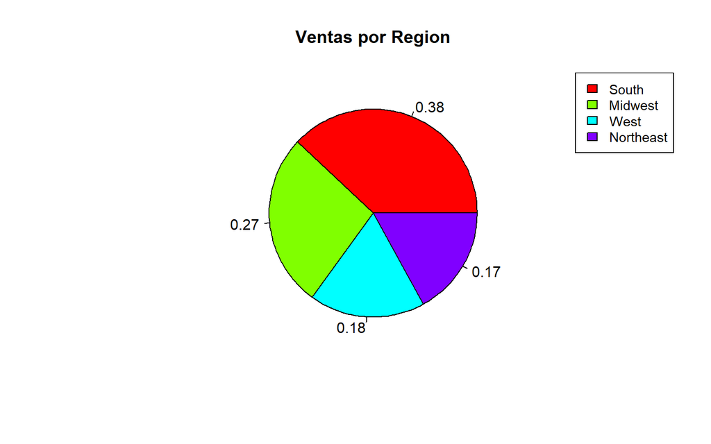

### 2.- Ventas por Categoría de producto

Ahora lo que procederemos a conocer es:

> - ¿Qué categorías generan más ganancias en las ventas?

Para poder entender mejor cuales son las categorias de productos donde se tienen mayores ganancias recurriremos a un análisis a través de diagramas de barras

```
##  [1] "Beauty & Grooming"  "Mobiles & Tablets"  "Superstore"
##  [4] "Computing"          "Men's Fashion"      "Women's Fashion"
##  [7] "Home & Living"      "Soghaat"            "Kids & Baby"
## [10] "Health & Sports"    "School & Education" "Appliances"
## [13] "Entertainment"      "Others"             "Books"
```

|  | Group.1 | x |
| --- | --- | --- |
| 10 | Mobiles &amp; Tablets | 270048296.51141 |
| 1 | Appliances | 68620220.1927 |
| 5 | Entertainment | 61682792.406 |
| 11 | Others | 21695551.67698 |
| 4 | Computing | 20415006.65798 |
| 15 | Women's Fashion | 11174647.41034 |
| 9 | Men's Fashion | 8421805.74526 |
| 2 | Beauty &amp; Grooming | 4241015.20668 |
| 14 | Superstore | 4124067.63505 |
| 7 | Home &amp; Living | 2923075.54798 |

[output cut: 5 more lines]

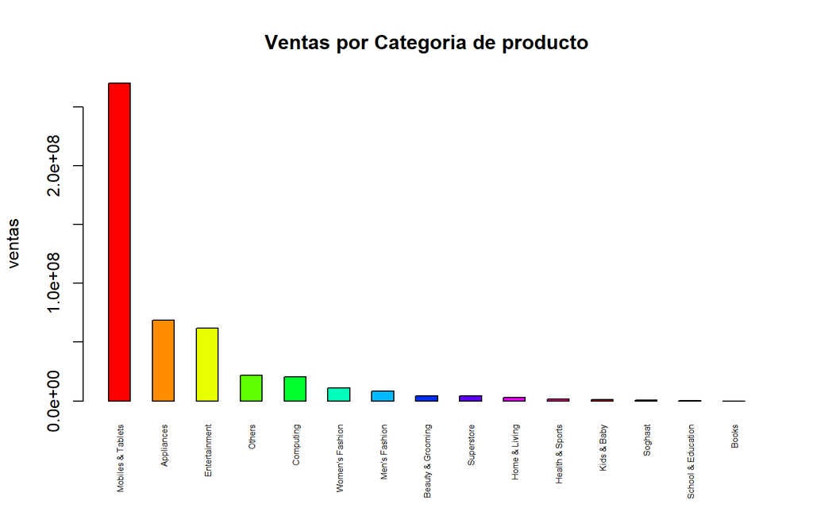

Por el diagrama podemos saber que las categorías de productos *“Mobiles & Tablets”*, *“Appliances”* y *“Entertainment”* son lo que tienen mayores ventas. Asimismo, no debemos descartar que no se tiene la categoria *“otros”*, esta se situa como la cuarta categoría mas vendida. No obstante, no podemos determinar a que productos hace referencia.

### 3.- Ventas Por Status

Ahora lo que procederemos a conocer es:

> - ¿Cuales son los Status por ventas?

Para ello vamos a realizar un diagrama de barras donde podamos mostrar cuales son los estatus más comunes de nuestro registro de ventas

|  | Group.1 | x |
| --- | --- | --- |
| 1 | canceled | 270287448.28359 |
| 4 | complete | 129117902.9188 |
| 12 | received | 41925522.08295 |
| 6 | order_refunded | 32736076.26879 |
| 13 | refund | 1647643.06934 |
| 3 | cod | 568980.665 |
| 7 | paid | 396232.0711 |
| 2 | closed | 228408.2 |
| 5 | holded | 220572.7 |
| 9 | pending | 197331.942 |

[output cut: 3 more lines]

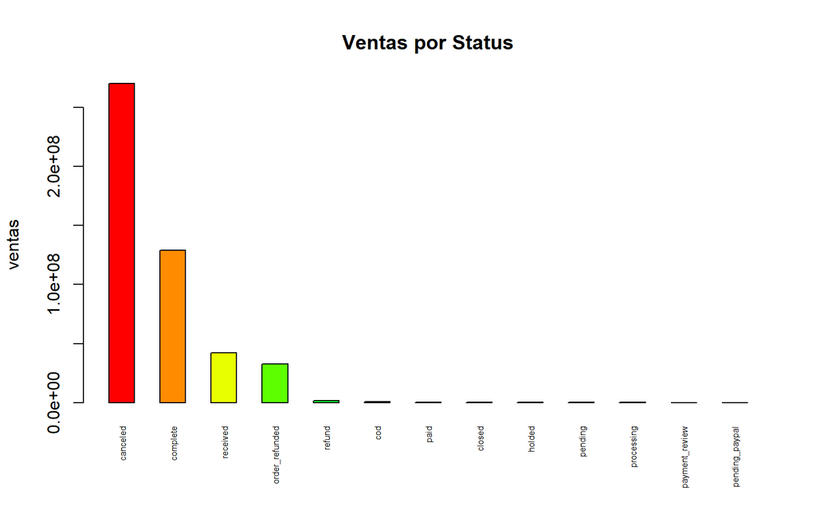

Por el diagrama podemos saber que el status *“Cancelado”* , *Completado* y *“Recibido”* son los más frecuentes. Asimismo, podemos agregar que los de estatus “cancelado” representan a las ventas completamente pagadas, las “completado” aquellas que fueron completadas no obstante el pago sigue pendiente y por “order_refunded” aquellas que fueron reenbolsadas

### 4.- Ventas Por Metodo de Pago

Ahora lo que procederemos a conocer es:

> - ¿Que tipo de pago es el mas usado?

Para ello vamos a realizar un diagrama de barras donde podamos mostrar cual es el tipo de pago más común de nuestro registro de ventas

|  | Group.1 | x |
| --- | --- | --- |
| 6 | Easypay | 111147336.72153 |
| 8 | easypay_voucher | 94588995.076 |
| 2 | bankalfalah | 90940071.68095 |
| 13 | Payaxis | 74943723.56209 |
| 4 | cod | 63365429.25 |
| 10 | jazzvoucher | 15588729.548 |
| 7 | Easypay_MA | 14527147.591 |
| 11 | jazzwallet | 4924143.67 |
| 5 | customercredit | 3940592.441 |
| 1 | apg | 3166301.841 |

[output cut: 3 more lines]

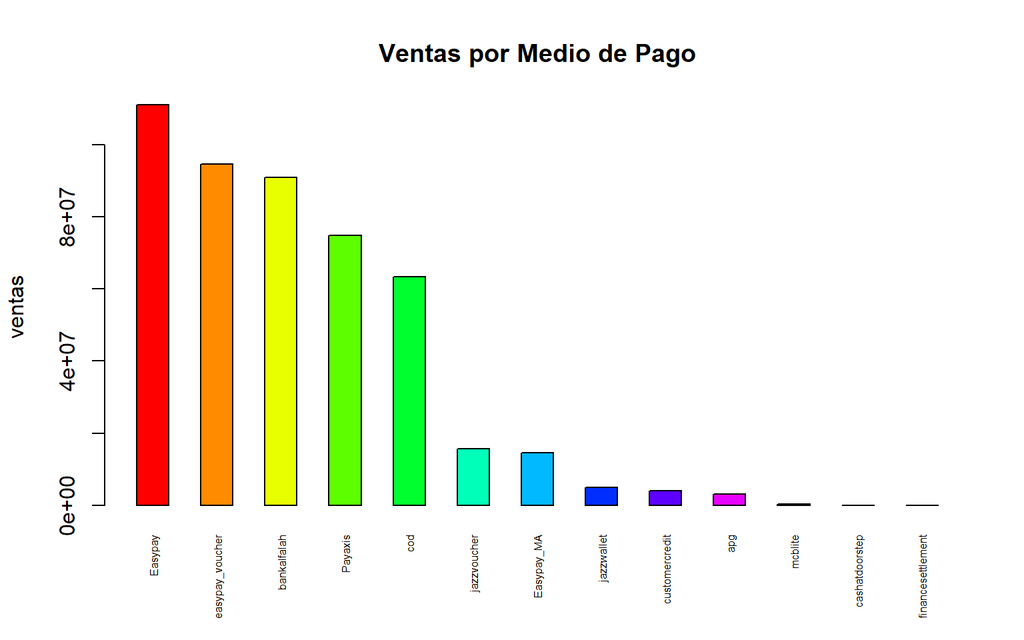

Interpretando el diagrama conocemos que el método de pago mas usados son *“Easypay”*,*Easypay_voucher*, *bankalfalh* y *Payaxis*.

### 5.- Ventas Por Genero

Por otro lado, queremos conocer lo siguiente:

> - ¿Que genero(hombres o mujeres) tiene mayores ventas?

Por lo tanto vamos a agrupar las ventas realizadas por hombres y mujeres y encontramos que :

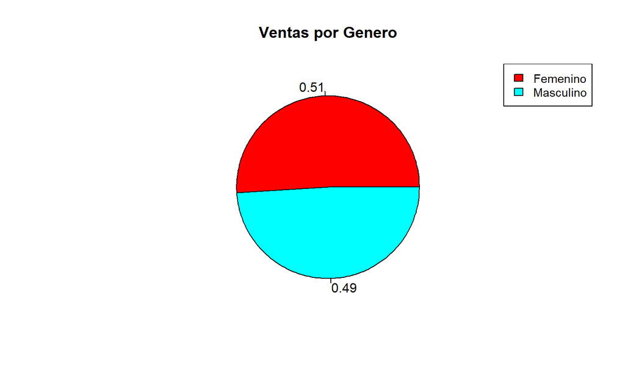

# Análisis Inferencial

Realizaremos los siguientes analisis con las 3 categorias con mayores ventas :

- Mobiles & Tablets
- Appliaances
- Entertainment

```
## filter (grouped): removed 224,628 rows (78%), 61,759 rows remaining
```

```
## top_n: removed 4,879 rows (>99%), 10 rows remaining
```

|  | Group.1 | x |
| --- | --- | --- |
| 1 | MATSAM59DB757FB47A2 | 13914025.02126 |
| 2 | MATSAM5B10F7E2AC8C1 | 12516539.5 |
| 3 | MATSAM59DB75ADB2F80 | 10181758.41008 |
| 4 | MATSAM5B1509B4696EA | 4897459.5 |
| 5 | MATSAM5B10F91A9B6AB | 4631858.9 |
| 6 | MATSAM59D74470AD085 | 4585161.2 |
| 7 | MATSAM5A0BFFF19C40A | 4428858.51672 |
| 8 | MATSAM5A7463EE3C1A5 | 4084165.764 |
| 9 | MATSAM5B10F2272EBD9 | 3811334.8 |
| 10 | MATSAM5A9F892ECDF73 | 3027310.213 |

```r
appliances<- usaStore%>%group_by(total)%>%filter(category %in% c("Appliances"))
```

```
## filter (grouped): removed 253,353 rows (88%), 33,034 rows remaining
```

```r
appliances <- aggregate(x=appliances$total,by=list(appliances$sku), FUN=sum)
appliances <- appliances[order(appliances$x,decreasing = TRUE),]
#Obtengo el top 10
appliances <- appliances %>% top_n(10)
```

```
## top_n: removed 3,656 rows (>99%), 10 rows remaining
```

```r
#Lo ingreso en una tabla
datatable(appliances)
```

|  | Group.1 | x |
| --- | --- | --- |
| 1 | APPGRE5A81C19C14F44 | 2476892.24 |
| 2 | APPKEN5A7C191D84D3C | 2061836.196 |
| 3 | APPORI5AE98573655FB | 1279268.913 |
| 4 | APPHAI59BFB2E94E951 | 1198154.062 |
| 5 | APPKEN5A7C22929B6DE | 917715.715 |
| 6 | APPDAW59FF034935DBA | 715912.30496 |
| 7 | APPKEN59F6F07C6DBBD | 664587.15272 |
| 8 | APPDAW59F97AFF95276 | 646866.18958 |
| 9 | APPPEL59FF42F50CAD3 | 632055.6 |
| 10 | APPDAW5AAA440CD4969 | 614149.945 |

```r
Entertainment<- usaStore%>%group_by(total)%>%filter(category %in% c("Entertainment"))
```

```
## filter (grouped): removed 269,035 rows (94%), 17,352 rows remaining
```

```r
Entertainment <- aggregate(x=Entertainment$total,by=list(Entertainment$sku), FUN=sum)
Entertainment <- Entertainment[order(Entertainment$x,decreasing = TRUE),]
#Obtengo el top 10
Entertainment <- Entertainment %>% top_n(10)
```

```
## top_n: removed 1,250 rows (99%), 10 rows remaining
```

```r
#Lo ingreso en una tabla
datatable(Entertainment)
```

|  | Group.1 | x |
| --- | --- | --- |
| 1 | ENTECO5A7FE80D6C830 | 3346168.224 |
| 2 | ENTSAM5A7BE6883BCB7 | 2965798.799 |
| 3 | ENTECO5A0C1CCF5C177 | 2508725.69026 |
| 4 | ENTNOB5A4633C950FAD | 2276579.094 |
| 5 | ENTECO5A0C00E345122 | 2186788.22282 |
| 6 | ENTNOB5A14947A21475 | 2151524.739 |
| 7 | ENTTCL5A7FEF9523346 | 1898965.24 |
| 8 | ENTSAM5A0BF25AA030B | 1563982.2 |
| 9 | ENTORI5A829F3B38644 | 1435301.071 |
| 10 | ENTORI5A8D3C794E5AC | 1370071.213 |

## Correlación

```
## 'data.frame':    286387 obs. of  5 variables:
##  $ cant_ordened   : num  2 3 2 2 11 2 2 2 2 2 ...
##  $ price          : num  328.5 56 21.6 62.5 35.9 ...
##  $ discount_amount: num  0 0 0 0 0 0 0 0 0 0 ...
##  $ total          : num  657 168 43.2 125 394.9 ...
##  $ age            : num  41 37 36 63 33 75 75 75 43 43 ...
```

```
##                 cant_ordened price discount_amount total   age
## cant_ordened            1.00 -0.10            0.02 -0.05  0.00
## price                  -0.10  1.00            0.24  0.93 -0.01
## discount_amount         0.02  0.24            1.00  0.29  0.00
## total                  -0.05  0.93            0.29  1.00 -0.01
## age                     0.00 -0.01            0.00 -0.01  1.00
```

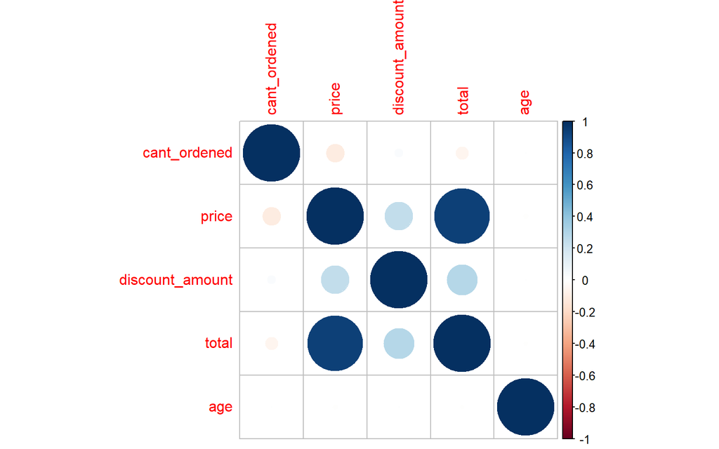

#Correlación menor a cero: Si la correlación es menor a cero, significa que es negativa, es decir, que las variables se relacionan inversamente. Cuando el valor de alguna variable es alto, el valor de la otra variable es bajo. Mientras más próximo se encuentre a -1, más clara será la covariación extrema.

# Ajustes de Distribución

## Ventas según categoría

Deseo conocer cual será el pronostico de ventas de la categoría de ventas mas vendida

```r
usaStore <- usaStore[!(usaStore$category==""),]

#Por lo tanto haré un análisis de los registros de venta de las ventas de categoria "mobiles and tables"


usaStore_Tablet <- usaStore %>% filter(usaStore$category=="Mobiles & Tablets")
```

```
## filter: removed 224,628 rows (78%), 61,759 rows remaining
```

```r
venta_usaStore_tablets <- usaStore_Tablet$total

#Diagrama de cullen and Frey de cantidades de ventas de tablets and mobiles


#descdist(venta_usaStore_tablets, boot=1000)
```

Vamos a validar cual de los tres puede ajustarse mas :

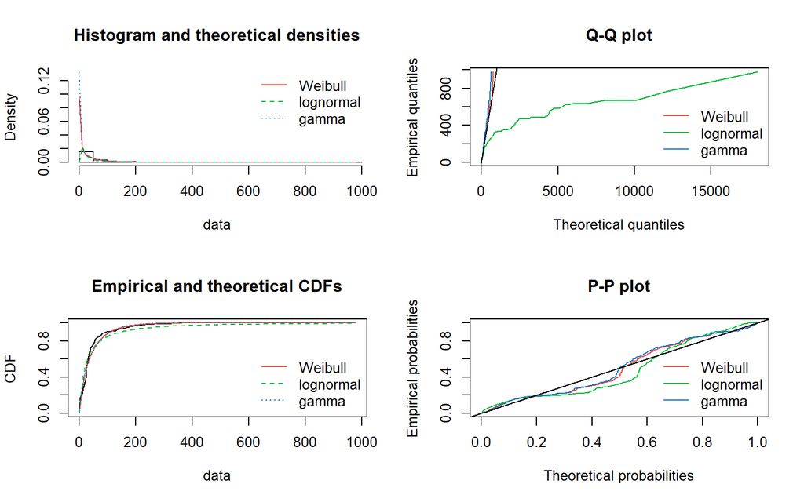

```r
fit_gamma  <- fitdist(venta_usaStore_tablets/100, "gamma")
#summary(fit_gamma)

fit_lognormal <- fitdist(venta_usaStore_tablets/100, "lnorm")
#summary(fit_lognormal)

fit_weillbul <- fitdist(venta_usaStore_tablets/100, "weibull")
#summary(fit_weillbul)


par(mfrow = c(2,2))
plot.legend <- c("Weibull","lognormal","gamma")



denscomp(list(fit_weillbul,fit_lognormal,fit_gamma),legendtext = plot.legend)
qqcomp(list(fit_weillbul,fit_lognormal,fit_gamma),legendtext = plot.legend)
cdfcomp(list(fit_weillbul,fit_lognormal,fit_gamma),legendtext = plot.legend)
ppcomp(list(fit_weillbul,fit_lognormal,fit_gamma),legendtext = plot.legend)
```

Se puede observar que el ajuste de distribución que se ajusta mas es “weibull”.

| Tipo de distribución | AIC obtenido |
| --- | --- |
| Gamma | 585890.6 |
| Lognormal | 598295.8 |
| Weillbul | 585425.9 |

Generación de la muestra:

```r
estimacion_venta <- rweibull(360,0.818221,3912.519211)
summary(estimacion_venta)
```

```
##     Min.  1st Qu.   Median     Mean  3rd Qu.     Max.
##     2.73   872.85  2498.91  4264.59  5459.45 30551.67
```

## Ventas según tipo de Pago :

Sabemos que el tipo de pago más usado es “Easypay” por lo tanto realizaremos la estimación en base a este metodo de pago. Cual es el promedio de ingresos a recibir para los próximos 360 días

```r
easypay_usaSales <- usaStore %>% filter(usaStore$payment_method=="Easypay")
```

```
## filter: removed 216,708 rows (76%), 69,679 rows remaining
```

```r
summary(easypay_usaSales$total)
```

```
##    Min. 1st Qu.  Median    Mean 3rd Qu.    Max.
##     1.0   159.8   462.0  1595.1  2000.0 64000.0
```

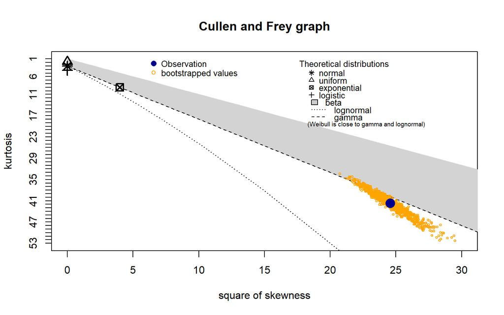

```
## summary statistics
## ------
## min:  1   max:  64000
## median:  462
## mean:  1595.134
## estimated sd:  2926.587
## estimated skewness:  4.955492
## estimated kurtosis:  41.67185
```

```r
descdist(easypay_usaSales$total, boot=1000)
```

Como se puede observar en el diagrama de cullen and frey se tiene que los ajustes de distribución que mas puede ir con el modelo son “lognormal”, “weibull” y “gamma”

Vamos a validar cual de los tres puede ajustarse mas :

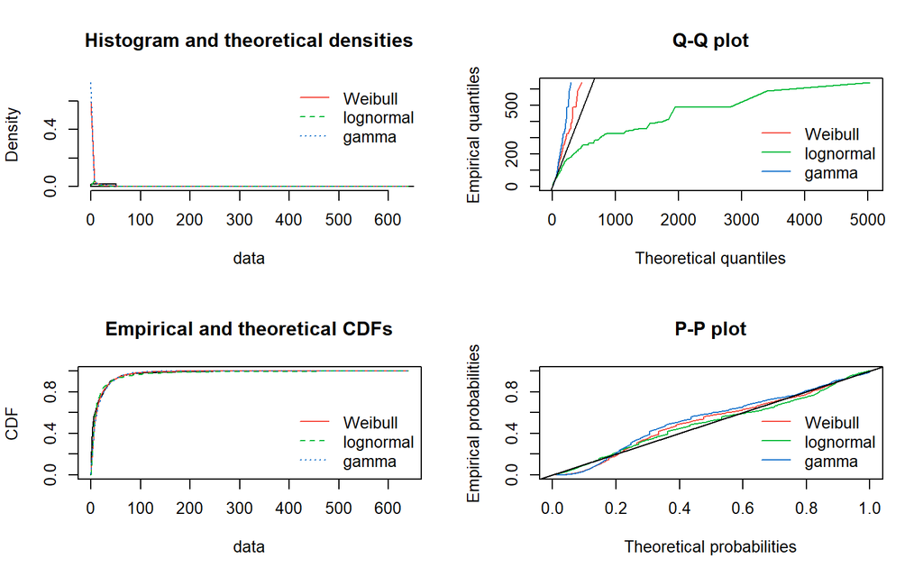

```r
#https://stackoverflow.com/questions/53557022/error-code-100-fitting-exp-distribution-using-fitdist-in-r
fit_gamma  <- fitdist((easypay_usaSales$total)/100, "gamma")
#summary(fit_gamma)

fit_lognormal <- fitdist((easypay_usaSales$total)/100, "lnorm")
#summary(fit_lognormal)

fit_weillbul <- fitdist((easypay_usaSales$total)/100, "weibull")
#summary(fit_weillbul)


par(mfrow = c(2,2))
plot.legend <- c("Weibull","lognormal","gamma")



denscomp(list(fit_weillbul,fit_lognormal,fit_gamma),legendtext = plot.legend)
qqcomp(list(fit_weillbul,fit_lognormal,fit_gamma),legendtext = plot.legend)
cdfcomp(list(fit_weillbul,fit_lognormal,fit_gamma),legendtext = plot.legend)
ppcomp(list(fit_weillbul,fit_lognormal,fit_gamma),legendtext = plot.legend)
```

Se puede observar que el ajuste de distribución que se ajusta mas es “LogNormal”.

| Tipo de distribución | AIC obtenido |
| --- | --- |
| Gamma | 505505.8 |
| Lognormal | 492585.6 |
| Weillbul | 499721 |

> **Conclusión**: Teniendo en cuenta el gráfico de Cullen y Frey, el grafico de comparativas así como el criterio del menor AIC, podemos decir que la variable venta sigue una distribución LogNormal

Generación de la muestra:

```r
#estimacion_weibull <- rweibull(360,0.6689953 ,1153.3599769)
#summary(estimacion_weibull)
estimacion_venta <- rlnorm(360,6.261626,1.582894)
summary(estimacion_venta)
```

```
##    Min. 1st Qu.  Median    Mean 3rd Qu.    Max.
##     9.2   179.6   535.1  1594.5  1388.9 32287.4
```

# Regresiones lineales

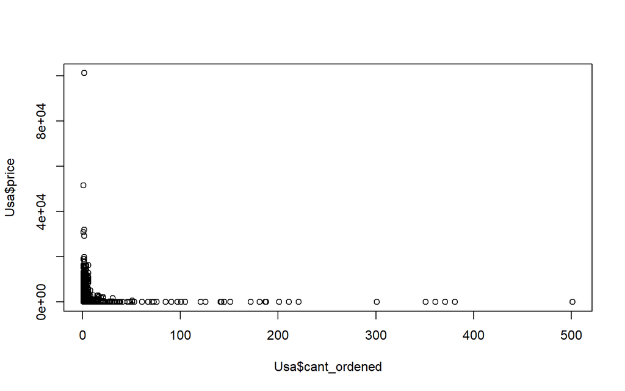

```r
Usa <- usaStore
plot(Usa$cant_ordened,Usa$price)
```

```r
modelo <- lm(Usa$cant_ordened ~ Usa$price, data=Usa)
summary(modelo)
```

```
##
## Call:
## lm(formula = Usa$cant_ordened ~ Usa$price, data = Usa)
##
## Residuals:
##    Min     1Q Median     3Q    Max
##  -2.24  -1.22  -1.06  -0.21 497.76
##
## Coefficients:
##               Estimate Std. Error t value Pr(>|t|)
## (Intercept)  3.243e+00  9.462e-03  342.77   <2e-16 ***
## Usa$price   -2.724e-04  4.881e-06  -55.82   <2e-16 ***
## ---
## Signif. codes:  0 '***' 0.001 '**' 0.01 '*' 0.05 '.' 0.1 ' ' 1
##
## Residual standard error: 4.549 on 286385 degrees of freedom
## Multiple R-squared:  0.01076,    Adjusted R-squared:  0.01076
## F-statistic:  3116 on 1 and 286385 DF,  p-value: < 2.2e-16
```

Que la recta se ajuste a los datos no significa que el modelo sea correcto, depende del uso que queramos darle.

Si sólo pretendemos hallar la relación entre dos variables, con calcular la recta de mínimos cuadrados es suficiente.

Si queremos verificar que tena una buena relación lineal, con el fin de inferir/ predecir con la recta de regresión debemos comprobar que se verefican unas reglas ya establecidas y acepadas que aseguran que nuestro modelo es bueno, para su verificación realizaremos los seiguientes análisis.

### Análisis de correlación

Correlación: Mide el grado de relación lineal, calculamos la matriz de coeficientes de correlación:

```r
cor(Usa$cant_ordened,Usa$price)
```

```
## [1] -0.103746
```

Esta correlación es la forma abreviada del coeficiente de correlación de Pearson, la fórmula de utilización original sería:

```r
cor.test(Usa$cant_ordened, Usa$price, method = "pearson")
```

```
##
##  Pearson's product-moment correlation
##
## data:  Usa$cant_ordened and Usa$price
## t = -55.821, df = 286385, p-value < 2.2e-16
## alternative hypothesis: true correlation is not equal to 0
## 95 percent confidence interval:
##  -0.1073676 -0.1001216
## sample estimates:
##       cor
## -0.103746
```

### Análisis de los residuos

Normalidad: Los errores deben seguir una distribución normal

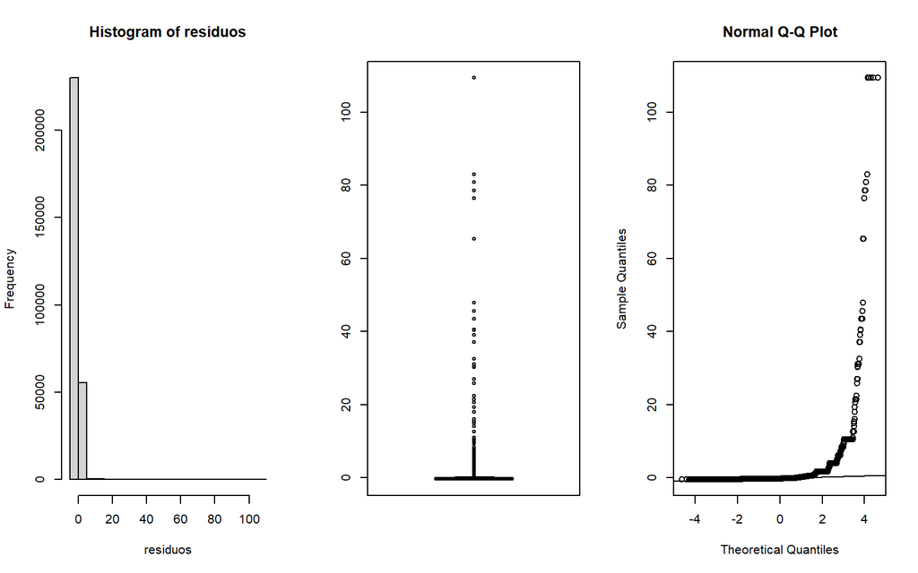

```r
residuos <- rstandard(modelo) #Residuos estándares del modelo ajustado (Completo)
par(mfrow=c(1,3)) #Divide la ventana en una fila y tres columnas
hist(residuos) #Histograma de los resiudos estandarizados
boxplot(residuos) #Diagrama de cajas de los residuos estandarizados

qqnorm(residuos) #Gráfico de cuantiles de los residuos estandarizados

qqline(residuos)
```

```r
par(mfrow=c(1,1)) #Devuelve la pantalla a su estado original
```

### Varianza constante:

La varianza de los errores es constante

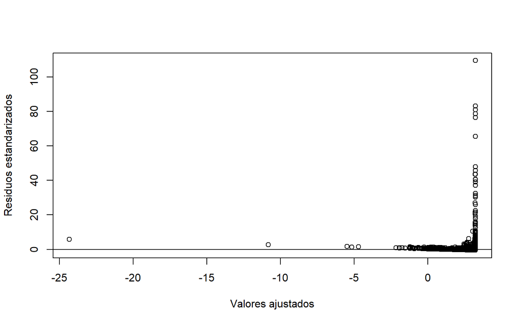

```r
plot(fitted.values(modelo), rstandard(modelo), xlab= "Valores ajustados", ylab= "Residuos estandarizados") # gráfico 2D de los valores ajustados vs. los residuos estandarizados
abline(h=0) # dibuja la recta en cero
```

Valores atípicos: La independencia de los errores

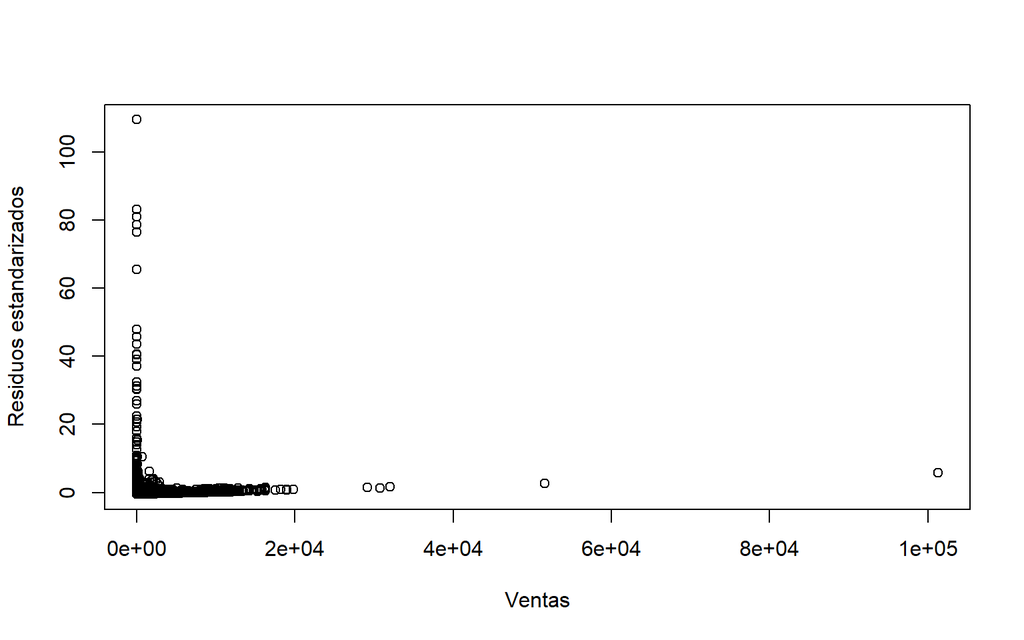

```r
plot(Usa$price,rstandard(modelo),xlab="Ventas",ylab="Residuos estandarizados")
```

### Visualización de la regresión

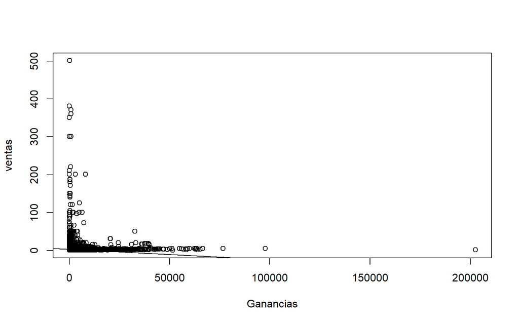

```r
plot(Usa$total, Usa$cant_ordened, xlab = "Ganancias",ylab= "ventas")
abline(modelo)
```

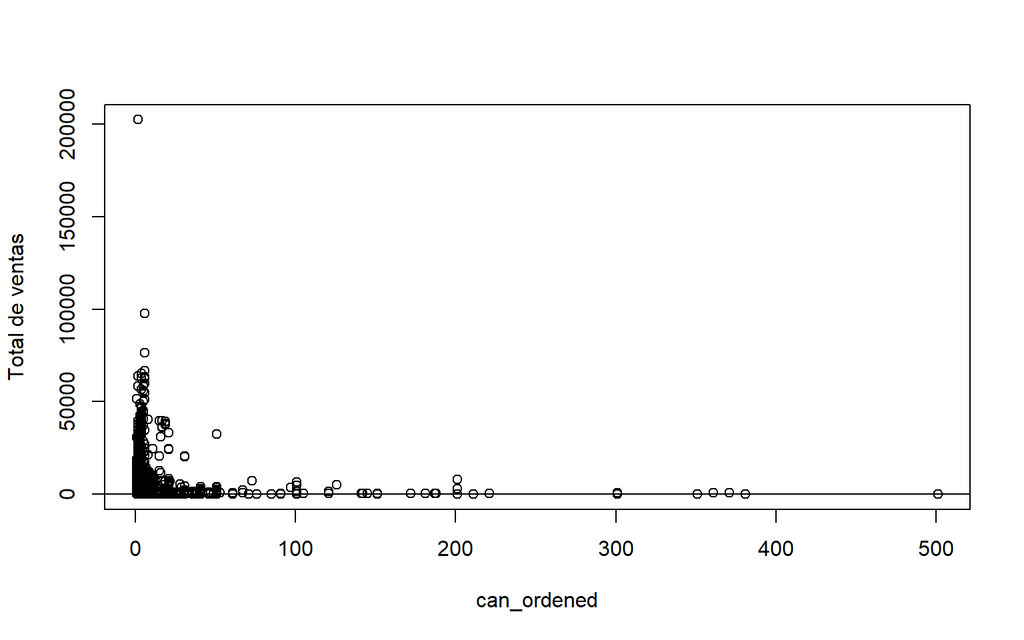

```r
plot(Usa$cant_ordened, Usa$total, xlab = "can_ordened",ylab= "Total de ventas")
abline(modelo)
```

### Análisis de regresión logística en R

Para realizar este analisis necesitamos estos requisitos:

Variable dependiente: no métrica (dicotómica)

Variables independientes: métricas y no métricas

Según la data que se tiene no contamos con variable dicotomicas

# Series Temporales

Relizamosla visualizacion de Datos en Cuartiles para conseguir los modelos en base a dicha serie de tiempo

```r
ventas.usa = ts(ventas, start = c(2020,1),end = c(2021,4),frequency = 4)
print(ventas.usa)
```

```
##       Qtr1  Qtr2  Qtr3  Qtr4
## 2020 657.0 168.0  43.2 125.0
## 2021 394.9 331.2 331.2 331.2
```

```r
start(ventas.usa);end(ventas.usa)
```

```
## [1] 2020    1
```

```
## [1] 2021    4
```

Para conocer el detalle de los valores en los cuatrimestres , realizamos un boxplot o diagrama de cajas para identificar la mediana y los datos atipicos dentro del total.

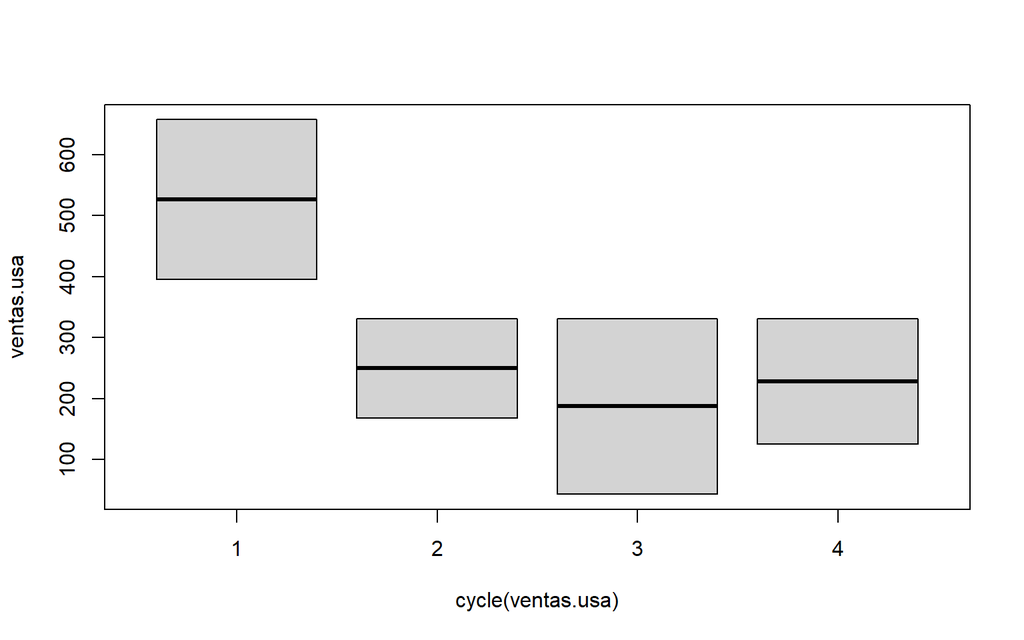

```r
boxplot(ventas.usa ~ cycle(ventas.usa))
```

```r
cycle(ventas.usa)
```

```
##      Qtr1 Qtr2 Qtr3 Qtr4
## 2020    1    2    3    4
## 2021    1    2    3    4
```

De acuerdo al bloxplot evidenciamos que la media para cada cuatrimestre es distinto y no se tiene valores atipicos en ninguno de ellos.

A continuacion validamos la clase del modelo, para que tengamos la certeza de que las formulas del modelo se van ejecutar de manera correcta.*

```r
class(ventas.usa)
```

```
## [1] "ts"
```

*La clase del modelo es correcta

## Analisis de Estacionariedad

vamos a graficar la descomposicion Aditiva y multiplicaiva para el caso en analisis, esto para conocer las tendencias de los valores en el tiempo, su evolucíón temporal.

### Modelo Aditivo

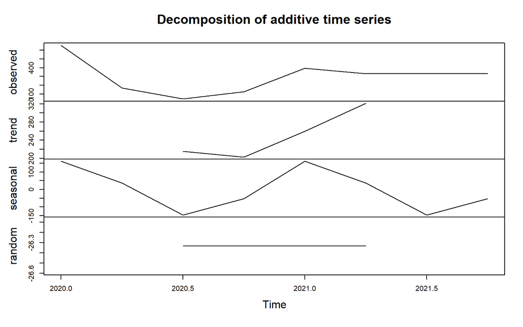

### Modelo Multiplicativo

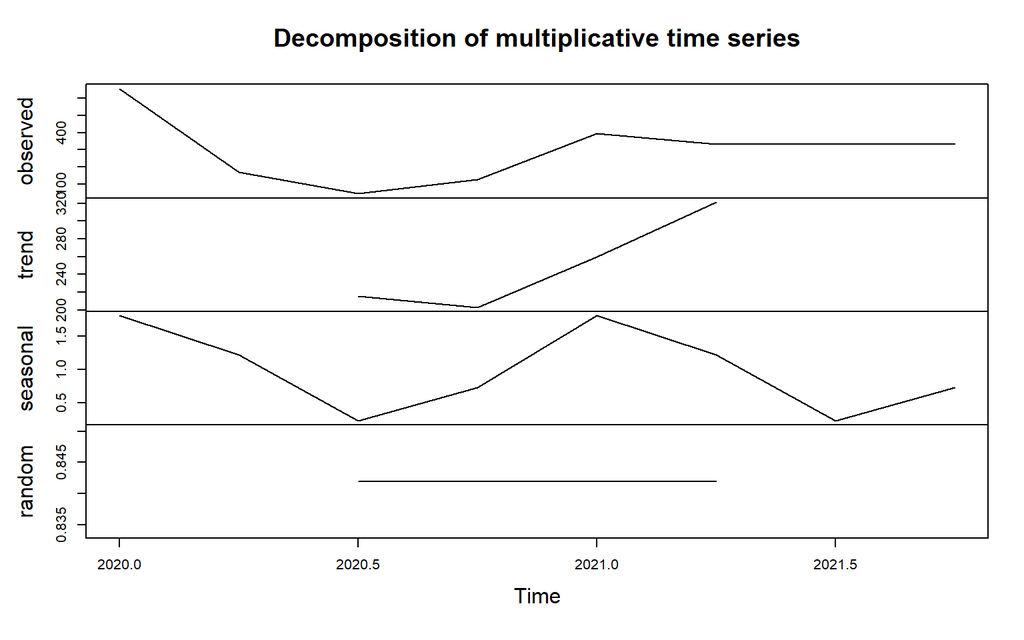

De acuerdo a las tendencias de descomposicion Aditivas y Multiplicativas, en ambos casos la variación es muy similar, por ello vamos a realizar los modelos correctos para una predicción

En los siguiente graficos muestra de otra manera la variación de los valores en el tiempo

### Polar seasonal Plot

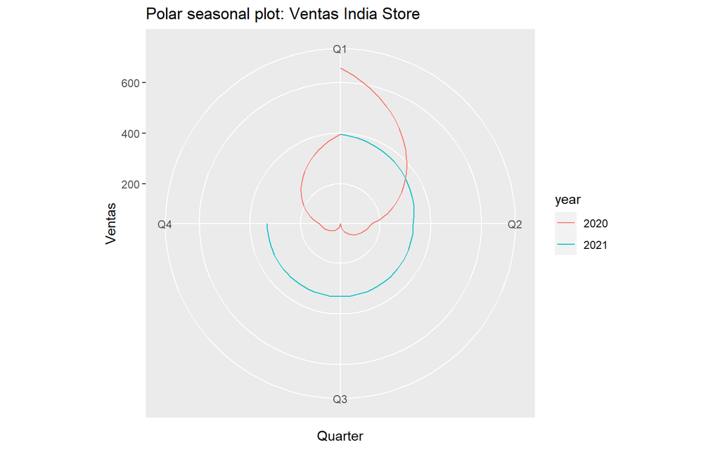

```r
ggseasonplot(ventas.usa, polar = TRUE) +
  ylab("Ventas") + ggtitle("Polar seasonal plot: Ventas India Store")
```

### Seasonal Plot

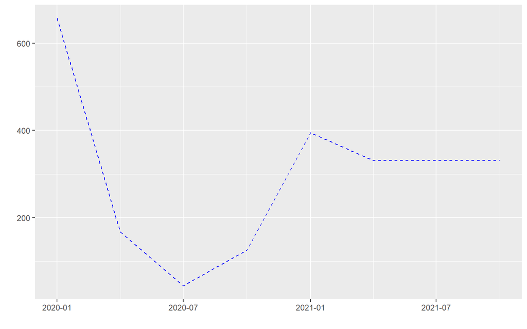

```r
autoplot(ventas.usa, ts.colour = "blue", ts.linetype = "dashed")
```

## Medidas de Autocorrelacion y Autocorrelacion Parcial

Ejecutar estas medidas nos van a ayudar a identificar los valores de series pasadas que nos ayudarán a realizar los pronosicos futuros, asi mismo determinar el orden de los procesos en un modelo ARIMA (p = Orden de Auto-regresion ,d = Orden de Integracion, q = Orden de media movil)

### Autocorrelación*

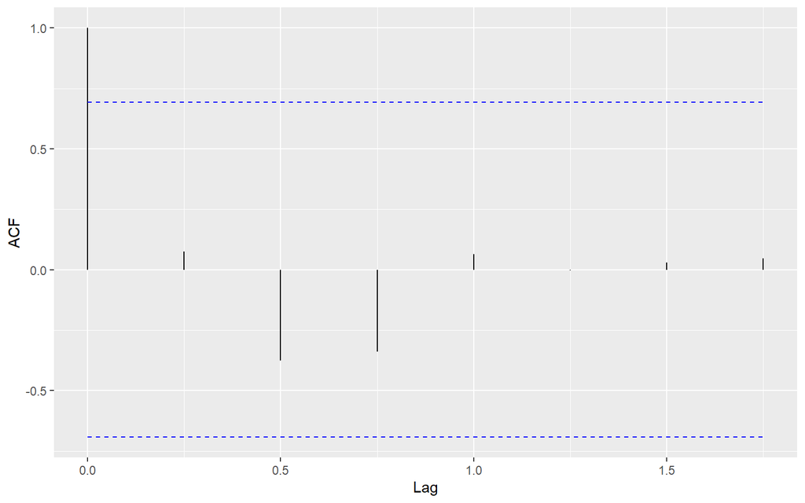

```r
autoplot(acf(ventas.usa, plot = FALSE))
```

### Autocorrelacion Parcial

Identficación de número de Autoregresivos

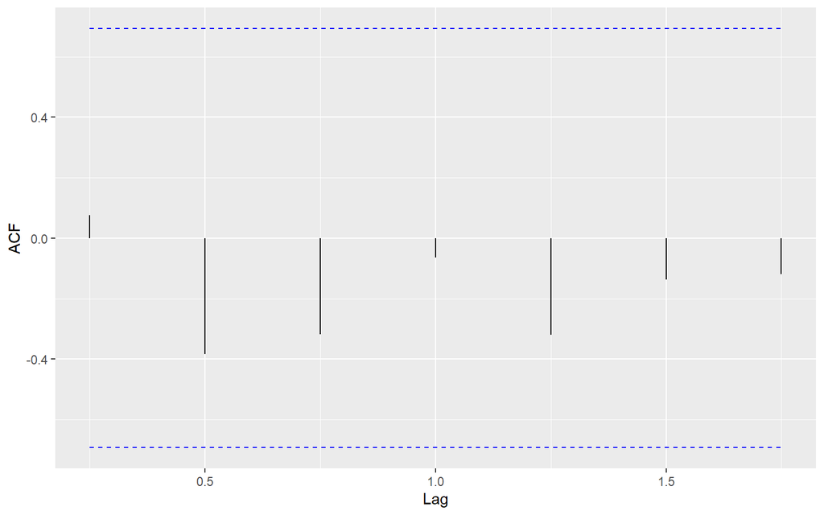

```r
autoplot(pacf(ventas.usa, plot = FALSE))
```

Para identificar que modelo es el correcto, realizaremoss primero el analisis con diferencias.

Validamos con Diff la estacionariedad

### Evaluación Dickey Fuller test

```r
diff.ventasu=diff(ventas.usa)
adf.test(diff.ventasu)
```

```
##
##  Augmented Dickey-Fuller Test
##
## data:  diff.ventasu
## Dickey-Fuller = -1.4685, Lag order = 1, p-value = 0.7749
## alternative hypothesis: stationary
```

Los resultados del test muestran p-value mayor a 0.05 por lo tanto no es estacionaria, entonces no podemos hacer monosticos con el modelo de diferencias.

Graficamos el modelo con las diferencias, para evidenciar la prueba antes realizada.

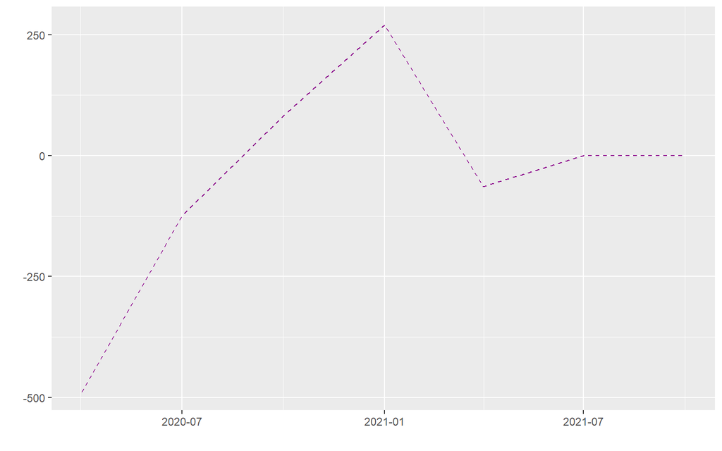

```r
diff.ventasUsa<-autoplot(diff(ventas.usa), ts.linetype = "dashed", ts.colour = "darkmagenta")
diff.ventasUsa
```

Rechazamos el modelo y proseguimos a realizar el modelo logaritmico

### Modelo con Logaritmo

```r
serielogUsa=log(ventas.usa)
serielogUsa
```

```
##          Qtr1     Qtr2     Qtr3     Qtr4
## 2020 6.487684 5.123964 3.765840 4.828314
## 2021 5.978633 5.802722 5.802722 5.802722
```

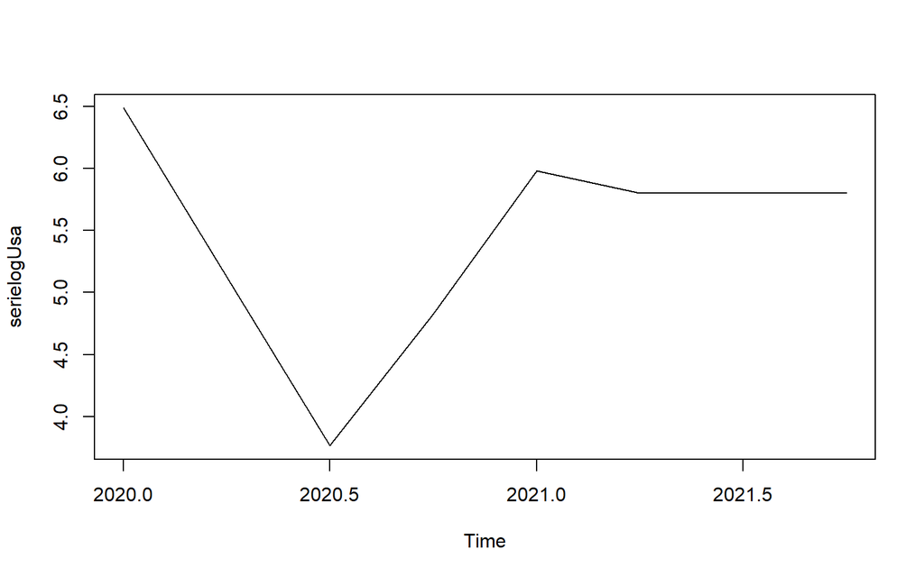

```r
plot(serielogUsa)
```

```r
adf.test(serielogUsa,alternative = "stationary")
```

```
##
##  Augmented Dickey-Fuller Test
##
## data:  serielogUsa
## Dickey-Fuller = -8.4548, Lag order = 1, p-value = 0.01
## alternative hypothesis: stationary
```

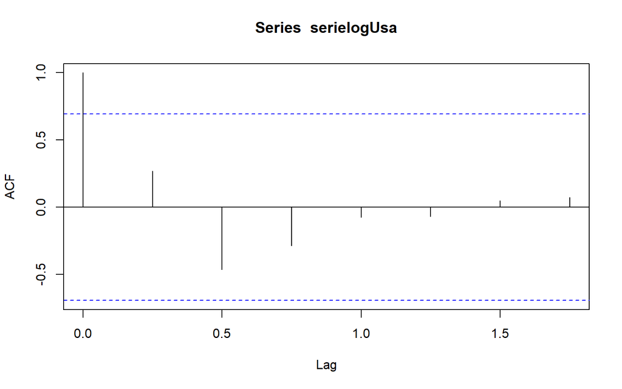

```r
#Autocorrelacion / Numero de medias moviles
acf(serielogUsa)
```

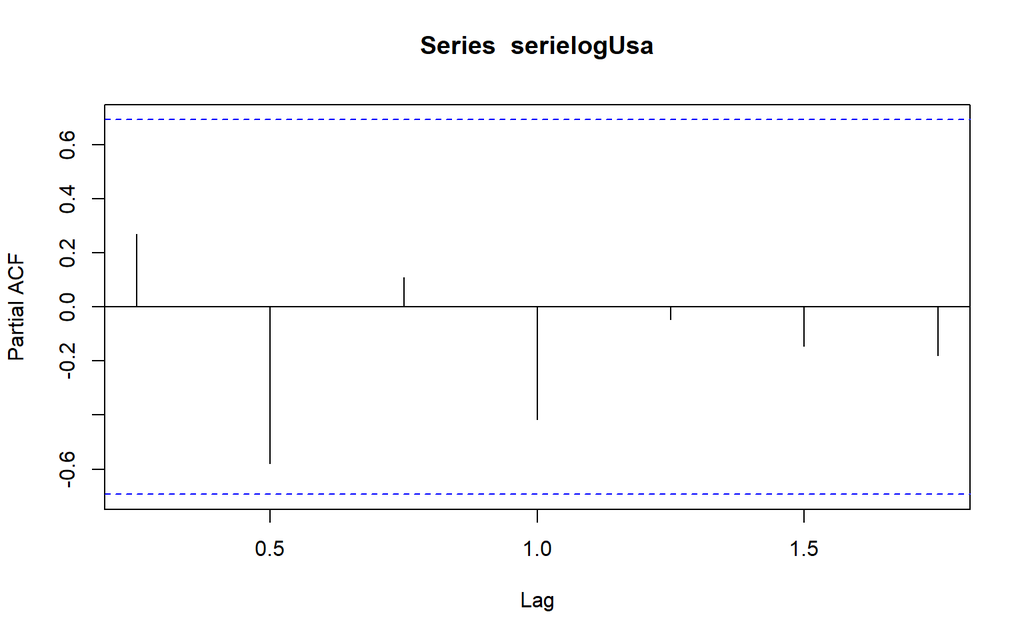

```r
#Autocorrelacion Parcial / numero de autoregresivos
pacf(serielogUsa)
```

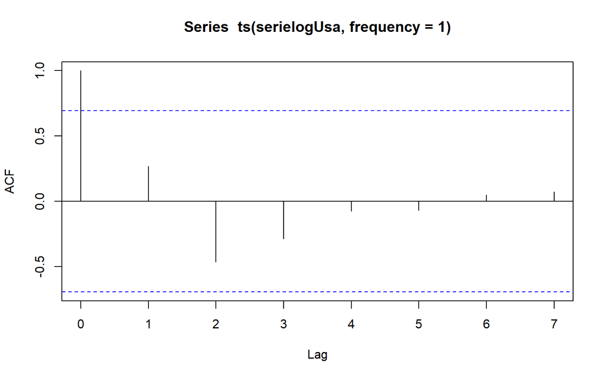

```r
# Las frecuencias de la serie tienen que ser igual a los resagos para ello se usa la siguiente funcion.
acf(ts(serielogUsa, frequency = 1))
```

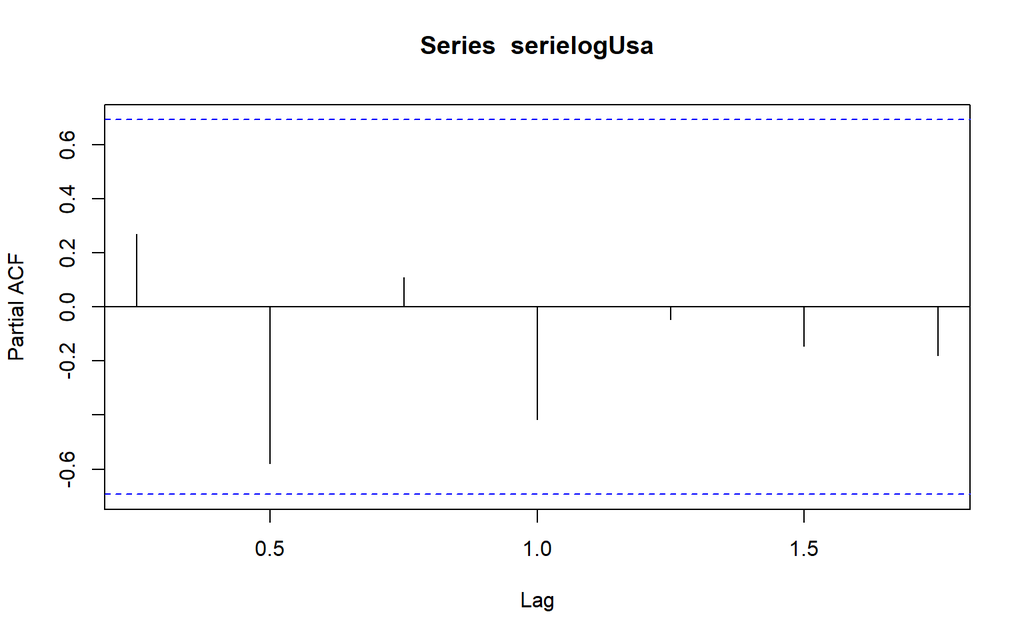

```r
pacf(serielogUsa, frequency=1)
```

Aplicamos el Modelo Arima, ya que tenemos el modelo estacional

1 autoregresivos 0 diferencia 0 media movil

```r
modelo1Usa = arima(ventas.usa,order = c(1,0,0))
modelo1Usa
```

```
##
## Call:
## arima(x = ventas.usa, order = c(1, 0, 0))
##
## Coefficients:
##          ar1  intercept
##       0.1394   305.3549
## s.e.  0.4735    76.8809
##
## sigma^2 estimated as 31255:  log likelihood = -52.76,  aic = 111.52
```

validamos si el modelo es bueno

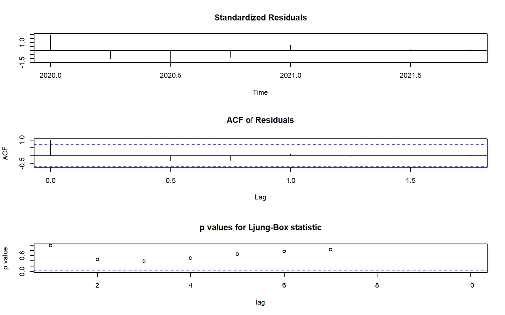

```r
tsdiag(modelo1Usa)
```

Validamos que sí hay ruido blanco ya que el P value es mayor a 0.05

```r
Box.test(residuals(modelo1Usa), type = "Ljung-Box")
```

```
##
##  Box-Ljung test
##
## data:  residuals(modelo1Usa)
## X-squared = 0.00049452, df = 1, p-value = 0.9823
```

### Graficamos los errores residuales

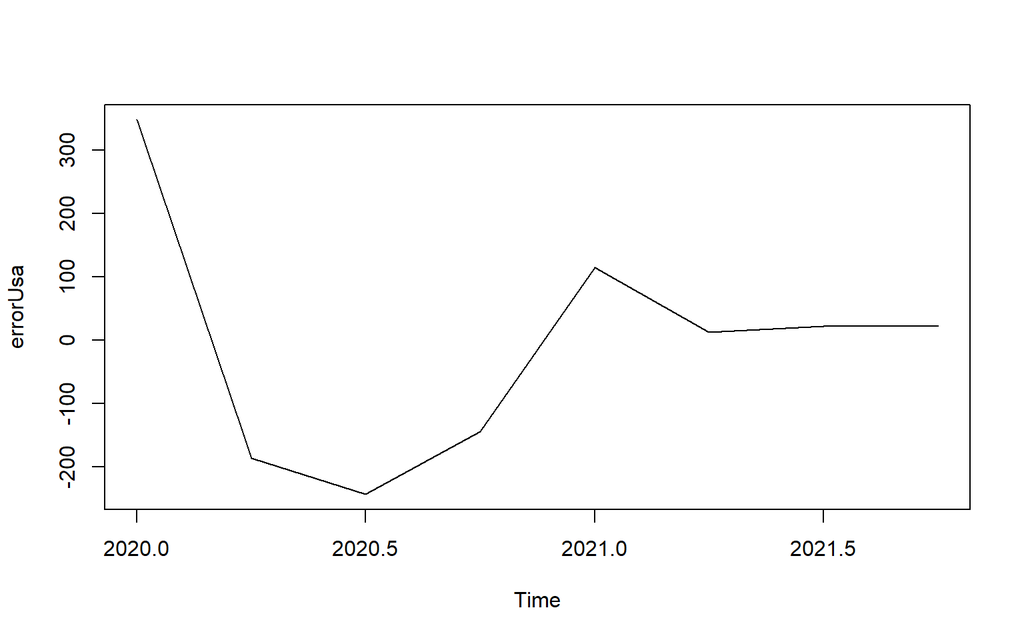

```r
errorUsa=residuals(modelo1Usa)
plot(errorUsa)
```

### Pronostico de proyección

```r
pronosticoUsa<- forecast::forecast(modelo1Usa, h = 10)
pronosticoUsa
```

```
##         Point Forecast    Lo 80    Hi 80     Lo 95    Hi 95
## 2022 Q1       308.9574 82.38986 535.5248 -37.54772 655.4624
## 2022 Q2       305.8570 77.09919 534.6149 -43.99790 655.7120
## 2022 Q3       305.4249 76.62470 534.2251 -44.49481 655.3446
## 2022 Q4       305.3647 76.56364 534.1657 -44.55630 655.2856
## 2023 Q1       305.3563 76.55523 534.1573 -44.56472 655.2772
## 2023 Q2       305.3551 76.55406 534.1561 -44.56589 655.2761
## 2023 Q3       305.3549 76.55389 534.1560 -44.56606 655.2759
## 2023 Q4       305.3549 76.55387 534.1559 -44.56608 655.2759
## 2024 Q1       305.3549 76.55387 534.1559 -44.56608 655.2759
## 2024 Q2       305.3549 76.55387 534.1559 -44.56608 655.2759
```

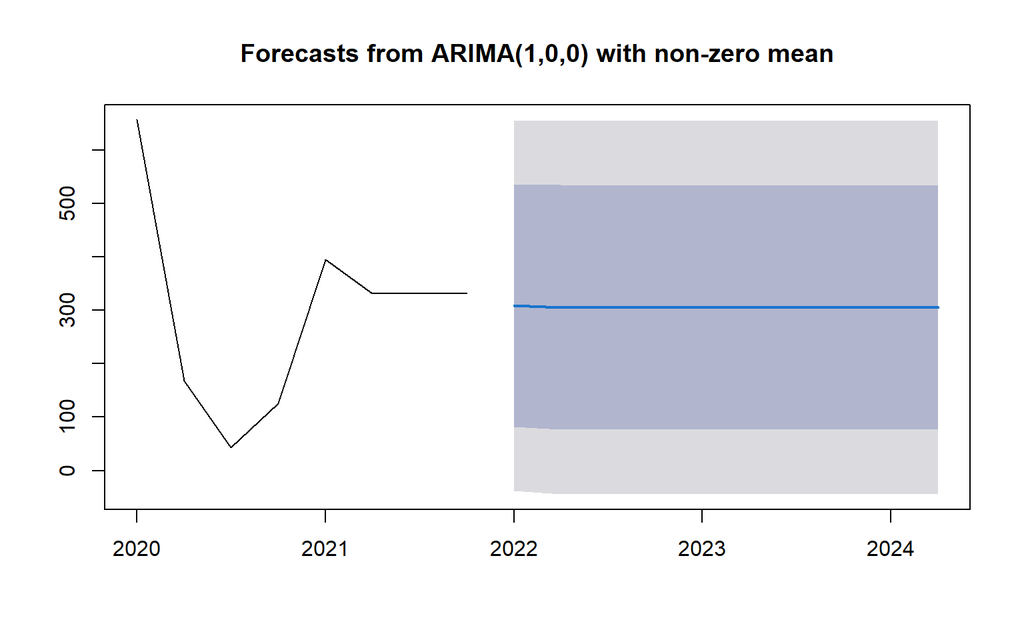

```r
plot(pronosticoUsa)
```

#*Concluimos en que el pronostico ARIMA con 1 Autocorregresivo, 0 diferencias y 0 medias moviles. Y se da como resultado que la tendencia en nuestro pronostico es constante.